https://www.geeksforgeeks.org/detect-and-remove-the-outliers-using-python/

# Outliers

Les outliers, qui s'écartent significativement de la norme, peuvent fausser les mesures de tendance centrale et influencer les analyses statistiques. Cet article explore les causes courantes des outliers, qu'il s'agisse d'erreurs ou d'introductions intentionnelles, et met en lumière leur importance dans l'identification des anomalies lors de l'analyse des données.

## Qu'est-ce qu'un outlier ?

Un outlier est un élément ou un objet de données qui s'écarte significativement des autres objets (considérés comme normaux). Identifier les outliers est crucial en statistique et en analyse de données, car ils peuvent avoir un impact considérable sur les résultats des analyses statistiques. L'analyse visant à détecter les outliers est appelée outlier mining (extraction des outliers).

Les outliers peuvent biaiser la moyenne (ou moyenne arithmétique) et affecter les mesures de tendance centrale, tout en influençant les résultats des tests de significativité statistique.

## Comment les outliers sont-ils causées ?

Les outliers peuvent être causés par une variété de facteurs, résultant souvent d'une variabilité inhérente aux données ou d'erreurs dans la collecte, la mesure ou l'enregistrement des données. Voici quelques causes courantes des outliers :

- **Erreurs de mesure :** Des erreurs dans les processus de collecte ou de mesure des données peuvent entraîner des outliers.
- **Erreurs d'échantillonnage :** Dans certains cas, des problèmes liés au processus d'échantillonnage peuvent engendrer des outliers.
- **Variabilité naturelle :** Une variabilité inhérente à certains phénomènes peut également donner lieu à des valeurs extrêmes. Certains systèmes peuvent présenter des valeurs extrêmes en raison de la nature du processus étudié.
- **Erreurs de saisie des données :** Les erreurs humaines lors de la saisie des données peuvent introduire des outliers.
- **Erreurs expérimentales :** Dans les contextes expérimentaux, des anomalies peuvent survenir en raison de facteurs incontrôlés, de dysfonctionnements d'équipement ou d'événements inattendus.
- **Échantillonnage de plusieurs populations :** Les données provenant de populations multiples aux caractéristiques différentes peuvent être combinées par inadvertance.
- **Outliers intentionnels :** Des outliers peuvent être introduits intentionnellement pour tester la robustesse des méthodes statistiques.

```python
# Importing
import sklearn
from sklearn.datasets import load_diabetes
import pandas as pd
import matplotlib.pyplot as plt

# Load the dataset
diabetics = load_diabetes()

# Create the dataframe
column_name = diabetics.feature_names
df_diabetics = pd.DataFrame(diabetics.data)
df_diabetics.columns = column_name
df_diabetics.head()
```

|  | age | sex | bmi | bp | s1 | s2 | s3 | s4 | s5 | s6 |
| --- | --- | --- | --- | --- | --- | --- | --- | --- | --- | --- |
| 0 | 0.038076 | 0.050680 | 0.061696 | 0.021872 | -0.044223 | -0.034821 | -0.043401 | -0.002592 | 0.019907 | -0.017646 |
| 1 | -0.001882 | -0.044642 | -0.051474 | -0.026328 | -0.008449 | -0.019163 | 0.074412 | -0.039493 | -0.068332 | -0.092204 |
| 2 | 0.085299 | 0.050680 | 0.044451 | -0.005670 | -0.045599 | -0.034194 | -0.032356 | -0.002592 | 0.002861 | -0.025930 |
| 3 | -0.089063 | -0.044642 | -0.011595 | -0.036656 | 0.012191 | 0.024991 | -0.036038 | 0.034309 | 0.022688 | -0.009362 |
| 4 | 0.005383 | -0.044642 | -0.036385 | 0.021872 | 0.003935 | 0.015596 | 0.008142 | -0.002592 | -0.031988 | -0.046641 |

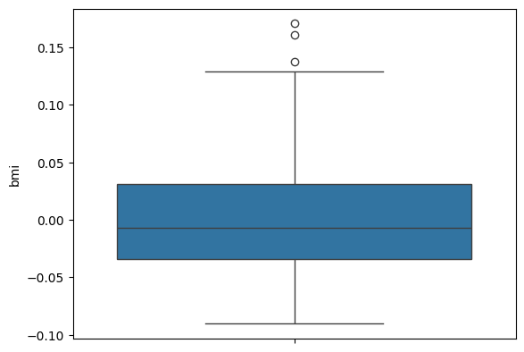

```python
# Box Plot
import seaborn as sns
sns.boxplot(df_diabetics['bmi'])
```

[figure not shown]

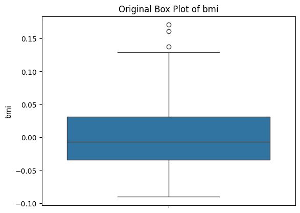

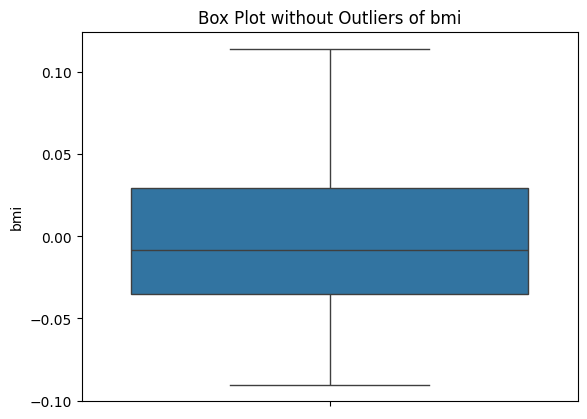

```python
import seaborn as sns
import matplotlib.pyplot as plt


def removal_box_plot(df, column, threshold):
    sns.boxplot(df[column])
    plt.title(f'Original Box Plot of {column}')
    plt.show()

    removed_outliers = df[df[column] <= threshold]

    sns.boxplot(removed_outliers[column])
    plt.title(f'Box Plot without Outliers of {column}')
    plt.show()
    return removed_outliers


threshold_value = 0.12

no_outliers = removal_box_plot(df_diabetics, 'bmi', threshold_value)
```

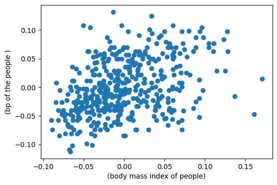

```python
fig, ax = plt.subplots(figsize=(6, 4))
ax.scatter(df_diabetics['bmi'], df_diabetics['bp'])
ax.set_xlabel('(body mass index of people)')
ax.set_ylabel('(bp of the people )')
plt.show()
```

## Visualisation et suppression des outlier à l'aide d'un nuage de points

Cette méthode est utilisée lorsque vous disposez de données numériques appariées, lorsque votre variable dépendante a plusieurs valeurs pour chaque valeur de la variable indépendante, ou lorsque vous essayez de déterminer la relation entre deux variables. En utilisant le nuage de points, il est également possible de détecter des outlier dans le jeu de données.

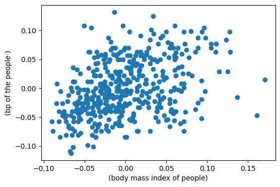

```python
fig, ax = plt.subplots(figsize=(6, 4))
ax.scatter(df_diabetics['bmi'], df_diabetics['bp'])
ax.set_xlabel('(body mass index of people)')
ax.set_ylabel('(bp of the people )')
plt.show()
```

### Suppression des outlier dans les colonnes BMI et BP combinées

Ici, la fonction `np.where()` de NumPy est utilisée pour trouver les positions (indices) où la condition `(df_diabetics['bmi'] > 0.12) & (df_diabetics['bp'] < 0.8)` est vraie dans le DataFrame **df_diabetics**. Cette condition identifie les outliers où **‘bmi’** est supérieur à 0.12 et **‘bp’** est inférieur à 0.8. Le résultat donne les indices des lignes et des colonnes des positions des outlier dans le DataFrame.

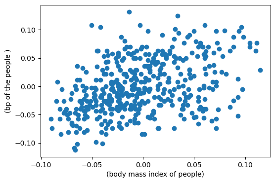

```python
import numpy as np
import seaborn as sns
import matplotlib.pyplot as plt

outlier_indices = np.where((df_diabetics['bmi'] > 0.12) & (df_diabetics['bp'] < 0.8))

no_outliers = df_diabetics.drop(outlier_indices[0])

# Scatter plot without outliers
fig, ax_no_outliers = plt.subplots(figsize=(6, 4))
ax_no_outliers.scatter(no_outliers['bmi'], no_outliers['bp'])
ax_no_outliers.set_xlabel('(body mass index of people)')
ax_no_outliers.set_ylabel('(bp of the people )')
plt.show()
```

# Z-score

Le Z-score, également appelé score standard, est une valeur qui permet de comprendre à quelle distance un point de données se trouve de la moyenne. En définissant une valeur seuil, on peut utiliser les Z-scores des points de données pour identifier les outlier.

*Zscore = (valeur_donnée - moyenne) / écart_type*

Dans cet exemple, nous calculons les Z-scores pour la colonne **‘age’** du DataFrame **df_diabetics** en utilisant la fonction `zscore` du module **stats** de SciPy. Le tableau résultant **z** contient les valeurs absolues des Z-scores pour chaque point de données de la colonne **‘age’**, indiquant de combien d’écarts-types chaque valeur s'écarte de la moyenne.

```python
from scipy import stats
import numpy as np
z = np.abs(stats.zscore(df_diabetics['age']))
print(z)
```

```
0      0.800500
1      0.039567
2      1.793307
3      1.872441
4      0.113172
         ...
437    0.876870
438    0.115937
439    0.876870
440    0.956004
441    0.956004
Name: age, Length: 442, dtype: float64
```

Maintenant, pour définir une valeur seuil pour les outlier, on choisit généralement **3.0**. En effet, 99,7 % des points de données se situent entre +/- 3 écarts-types (selon l'approche de la distribution gaussienne).

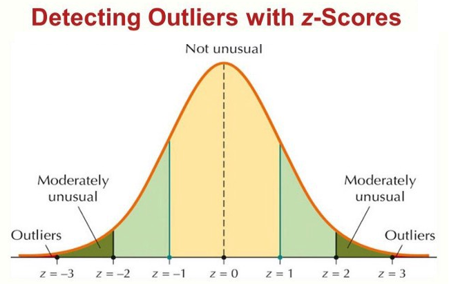

### Suppression des outlier avec le Z-Score

Supprimons les lignes où la valeur du Z-Score est supérieure à 2.

Dans cet exemple, une valeur seuil de **2** est définie, puis la fonction `np.where()` de NumPy est utilisée pour identifier les positions (indices) dans le tableau des Z-scores **z** où le Z-Score absolu est supérieur au seuil spécifié (**2**). Les positions des outlier dans la colonne **‘age’** sont affichées en fonction du critère du Z-Score.

```python
import numpy as np

threshold_z = 2

outlier_indices = np.where(z > threshold_z)[0]
no_outliers = df_diabetics.drop(outlier_indices)
print("Original DataFrame Shape:", df_diabetics.shape)
print("DataFrame Shape after Removing Outliers:", no_outliers.shape)
```

```
Original DataFrame Shape: (442, 10)
DataFrame Shape after Removing Outliers: (426, 10)
```

# IQR (Inter-Quartile Range)

L'approche de l'IQR (Inter-Quartile Range) pour identifier les outlier est l'une des plus couramment utilisées et les plus fiables dans le domaine de la recherche.

*IQR = Quartile3 – Quartile1*

Dans cet exemple, nous calculons l'intervalle interquartile (IQR) pour la colonne **‘bmi’** du DataFrame **df_diabetics**. La méthode commence par calculer le premier quartile (**Q1**) et le troisième quartile (**Q3**) en utilisant la méthode du point médian, puis détermine l'IQR comme la différence entre **Q3** et **Q1**. Cela fournit une mesure de la dispersion des 50 % des données centrales dans la colonne **‘bmi’**.

[figure not shown]

```python
# np.percentile usage:
# np.percentile(array, n) returns the nth percentile of the array

# IQR
Q1 = np.percentile(df_diabetics['bmi'], 25, method='midpoint')
Q3 = np.percentile(df_diabetics['bmi'], 75, method='midpoint')
IQR = Q3 - Q1
print(IQR)
```

```
0.06520763046978838
```

Pour définir les valeurs limites des outlier, on établit des bornes supérieures et inférieures en fonction de la plage normale du jeu de données. Ces bornes sont définies comme suit (on considère une valeur de **1.5*IQR**) :

- **upper = Q3 + 1.5*IQR**
- **lower = Q1 – 1.5*IQR**

Dans la formule ci-dessus, selon les statistiques, une augmentation de 0.5 de l'IQR est prise en compte (**new_IQR = IQR + 0.5*IQR**) pour inclure toutes les données se situant dans **2.7 écarts-types** de la distribution gaussienne.

```python
# Above Upper bound
upper = Q3+1.5*IQR
upper_array = np.array(df_diabetics['bmi'] >= upper)
print("Upper Bound:", upper)
print(upper_array.sum())

# Below Lower bound
lower = Q1-1.5*IQR
lower_array = np.array(df_diabetics['bmi'] <= lower)
print("Lower Bound:", lower)
print(lower_array.sum())
```

```
Upper Bound: 0.12879000811776306
3
Lower Bound: -0.13204051376139045
0
```

### Suppression des outliers dans un jeu de données en utilisant l'IQR

Dans cet exemple, nous utilisons la méthode de l'intervalle interquartile (IQR) pour détecter et supprimer les outlier dans la colonne **‘bmi’** du jeu de données sur le diabète.

La méthode calcule les limites supérieure et inférieure basées sur l'IQR, identifie les indices des outlier à l'aide de tableaux booléens, puis supprime les lignes correspondantes du DataFrame. Le résultat est un nouveau DataFrame avec les outlier exclues. Les dimensions du DataFrame avant et après la suppression des outlier sont affichées pour comparaison.

```python
# Importing
import sklearn
from sklearn.datasets import load_diabetes
import pandas as pd

# Load the dataset
diabetes = load_diabetes()

# Create the dataframe
column_name = diabetes.feature_names
df_diabetes = pd.DataFrame(diabetes.data)
df_diabetes .columns = column_name
df_diabetes .head()
print("Old Shape: ", df_diabetes.shape)

''' Detection '''
# IQR
# Calculate the upper and lower limits
Q1 = df_diabetes['bmi'].quantile(0.25)
Q3 = df_diabetes['bmi'].quantile(0.75)
IQR = Q3 - Q1
lower = Q1 - 1.5*IQR
upper = Q3 + 1.5*IQR

# Create arrays of Boolean values indicating the outlier rows
upper_array = np.where(df_diabetes['bmi'] >= upper)[0]
lower_array = np.where(df_diabetes['bmi'] <= lower)[0]

# Removing the outliers
df_diabetes.drop(index=upper_array, inplace=True)
df_diabetes.drop(index=lower_array, inplace=True)

# Print the new shape of the DataFrame
print("New Shape: ", df_diabetes.shape)
```

```
Old Shape:  (442, 10)
New Shape:  (439, 10)
```